# Visualizing OPUS binary files in R

Adrianne Seiden

2026-07-16

# Reading OPUS files

[source](https://spectral-cockpit.github.io/opusreader2/articles/opusreader2_introduction.html)

This code is modified from the original OPUSreader2 documentation vignettes/opusreader2_introduction.Rmd by Philip Baumann and Thomas Knecht. It reads OPUS binary files and extracts metadata and absorbance data, which can then be plotted.

## Plots & Metadata

The main function, `read_opus()`, reads one or more OPUS files and returns a nested list of class `list_opusreader2`. Each list contains both the spectral data and metadata for each file. The `dsn` argument is the data source name. It can be a character vector of folder paths (to read files recursively) or specific OPUS file paths. Start by testing the read_opus function on your corrected spectra folder, and saving the output of the first file.

```r
#load opusreader2 from github.com/spectral-cockpit
library(opusreader2)

#save the path to your corrected spectra
# # Mac path
# corr_spectra <- "/Users/adrianneseiden/Library/CloudStorage/Box-Box/Salk Institute Project/AKS Salk files/Adrianne_FTIRdata/Corrected_files" # nolint
#  # Windows path
# corr_spectra <- "C:/Users/adria/Box/Box-Box/Salk Institute Project/AKS Salk files/Adrianne_FTIRdata/Corrected_files" # nolint
# # Relative path
# corr_spectra <- "../Adrianne_FTIRdata/Corrected_files"

#save the data from your corrected files as 'data_test'
data_test <- read_opus(dsn = corr_spectra)
#check the names of the list
names(data_test)
>  [1] "AKS_suberin_miscanthus_H2O20_260629-0.0"
>  [2] "AKS_suberin_miscanthus_H2O30_260629-0.0"
>  [3] "AKS_suberin_miscanthus_H2Oinsol-milled_260716-0.0"
>  [4] "AKS_suberin_miscanthus_H2Oinsol-milled_260716-1.0"
>  [5] "AKS_suberin_miscanthus_NaOH20_260629-0.0"
>  [6] "AKS_suberin_miscanthus_NaOH20_260629-1.0"
>  [7] "AKS_suberin_miscanthus_NaOH30_260629-0.0"
>  [8] "AKS_suberin_miscanthus_NaOH30_260629-1.0"
>  [9] "AKS_suberin_miscanthus_raw-milled_260716-0.0"
> [10] "AKS_suberin_miscanthus_raw_260629-0.0"
> [11] "AKS_suberin_sorghum_H2Oinsol-milled_260716-0.0"
> [12] "AKS_suberin_sorghum_H2Oinsol-milled_260716-1.0"
> [13] "AKS_suberin_sorghum_raw-milled_260716-0.0"
> [14] "AKS_suberin_sorghum_raw-milled_260716-1.0"
> [15] "AKS_suberin_sorghum_raw-milled_260716-2.0"
> [16] "AKS_suberin_sorghum_raw_260702-1.0"
> [17] "AKS_suberin_sugarcane_H2Oinsol-milled_260716-0.0"
> [18] "AKS_suberin_sugarcane_H2Oinsol-milled_260716-1.0"
> [19] "AKS_suberin_sugarcane_raw-milled_260716-0.0"
> [20] "AKS_suberin_sugarcane_raw-milled_260716-1.0"
> [21] "AKS_suberin_sugarcane_raw_260702-0.0"
> [22] "AKS_suberin_sugarcane_raw_260702-1.0"
# define 'meas_1' as the first element of the 'data_test' list
meas_1 <- data_test[[1]]
```

Next I defined a function, plotSpectrum, to plot the spectral data from a single sample (meas_1)

```r
# data is a list containing OPUS file data, including absorbance and metadata.

plotSpectrum <- function(data) { # nolint: object_name_linter.
  ab_data <- data$ab
  if (!is.null(ab_data) &&
        !is.null(ab_data$wavenumbers) && !is.null(ab_data$data) &&
        is.numeric(ab_data$wavenumbers) && is.numeric(ab_data$data) &&
        length(ab_data$wavenumbers) == length(ab_data$data) &&
        all(is.finite(ab_data$wavenumbers)) && all(is.finite(ab_data$data))) {
    plot(
      ab_data$wavenumbers, ab_data$data, type = "l",
      xlab = "Wavenumber (cm⁻¹)", ylab = "Absorbance",
      main = data$basic_metadata$dsn_filename,
      xlim = rev(range(ab_data$wavenumbers))
    )
  } else {
    cat("Absorbance data not found or not valid in this file.\n")
    str(ab_data)
  }
}
plotSpectrum(meas_1)
```

[output not shown]

To view all the available data categories, run ‘names(meas_1)’ in the console. To view the parameters within these categories use str(meas_1$category_name) where ‘category_name’ is ‘basic_metadata’, ‘optics’, etc.

The *plotMetadata* function combines the plot and table for a single spectrum.

```r
plotMetadata <- function(data) { # nolint: object_name_linter.
  plotSpectrum(data)
  metadataTable(data)
}
plotMetadata(meas_1)
```

[output not shown]

Metadata

| Parameter | Value |
| --- | --- |
| File Name | AKS_suberin_miscanthus_H2O20_260629-0.0 |
| Timestamp | 2026-06-29 16:38:37 GMT+1 |
| Max Y | 0.210223510861397 |
| Min Y | -0.000367011467460543 |
| Aperture Setting | 6 mm |
| Scanner Velocity | 10.0A |
| Result Spectrum | TR |
| Resolution | 4 |
| Sample Scans | 128 |
| End Frequency | 600 |
| Start Frequency | 4000 |
| Duration | 106.716003417969 |
| Experiment (method) | MIR_Invenio R_ATR - RT-DLaTGs.xpm |

### Combined plot and table (folder)

The following for loop runs plotMetadata on each spectrum in the data_test list, which contains all the spectra in the folder. It will plot each spectrum and print its metadata below.

```r
for (i in seq_along(data_test)) {
  cat("#### Spectrum", i, ":", names(data_test)[i], "\n\n")
  data_i <- data_test[[i]]
  ab_data <- data_i$ab
  valid <- !is.null(ab_data) &&
    !is.null(ab_data$wavenumbers) && !is.null(ab_data$data) &&
    is.numeric(ab_data$wavenumbers) && is.numeric(ab_data$data) &&
    length(ab_data$wavenumbers) == length(ab_data$data) &&
    all(is.finite(ab_data$wavenumbers)) && all(is.finite(ab_data$data))
  if (valid) {
    plotSpectrum(data_i)
    print(metadataTable(data_i))
  } else {
    cat("Data not valid or missing for this spectrum.\n")
    str(ab_data)
  }
}
```

[output not shown]

#### Spectrum 1 : AKS_suberin_miscanthus_H2O20_260629-0.0

Metadata

| Parameter | Value |
| --- | --- |
| File Name | AKS_suberin_miscanthus_H2O20_260629-0.0 |
| Timestamp | 2026-06-29 16:38:37 GMT+1 |
| Max Y | 0.210223510861397 |
| Min Y | -0.000367011467460543 |
| Aperture Setting | 6 mm |
| Scanner Velocity | 10.0A |
| Result Spectrum | TR |
| Resolution | 4 |
| Sample Scans | 128 |
| End Frequency | 600 |
| Start Frequency | 4000 |
| Duration | 106.716003417969 |
| Experiment (method) | MIR_Invenio R_ATR - RT-DLaTGs.xpm |

#### Spectrum 2 : AKS_suberin_miscanthus_H2O30_260629-0.0

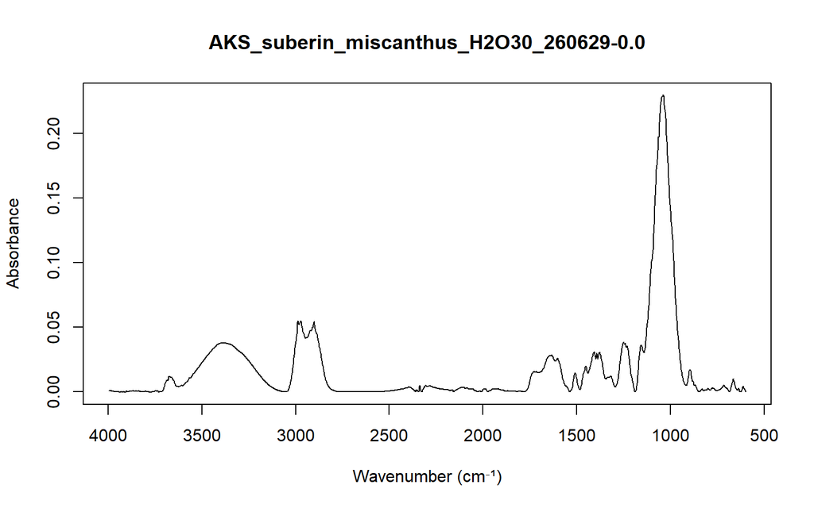

Metadata

| Parameter | Value |
| --- | --- |
| File Name | AKS_suberin_miscanthus_H2O30_260629-0.0 |
| Timestamp | 2026-06-29 16:38:43 GMT+1 |
| Max Y | 0.229553818702698 |
| Min Y | -0.000496726424898952 |
| Aperture Setting | 6 mm |
| Scanner Velocity | 10.0A |
| Result Spectrum | TR |
| Resolution | 4 |
| Sample Scans | 128 |
| End Frequency | 600 |
| Start Frequency | 4000 |
| Duration | 106.714996337891 |
| Experiment (method) | MIR_Invenio R_ATR - RT-DLaTGs.xpm |

#### Spectrum 3 : AKS_suberin_miscanthus_H2Oinsol-milled_260716-0.0

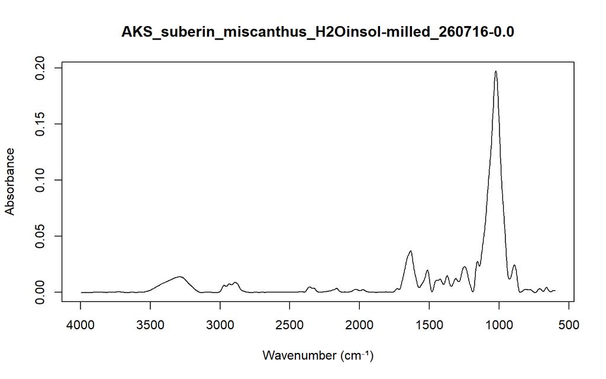

Metadata

| Parameter | Value |
| --- | --- |
| File Name | AKS_suberin_miscanthus_H2Oinsol-milled_260716-0.0 |
| Timestamp | 2026-07-16 16:20:00 GMT+1 |
| Max Y | 0.197334602475166 |
| Min Y | -0.000286152731860057 |
| Aperture Setting | 6 mm |
| Scanner Velocity | 10.0A |
| Result Spectrum | TR |
| Resolution | 4 |
| Sample Scans | 128 |
| End Frequency | 600 |
| Start Frequency | 4000 |
| Duration | 106.717002868652 |
| Experiment (method) | MIR_Invenio R_ATR - RT-DLaTGs_AKS.xpm |

#### Spectrum 4 : AKS_suberin_miscanthus_H2Oinsol-milled_260716-1.0

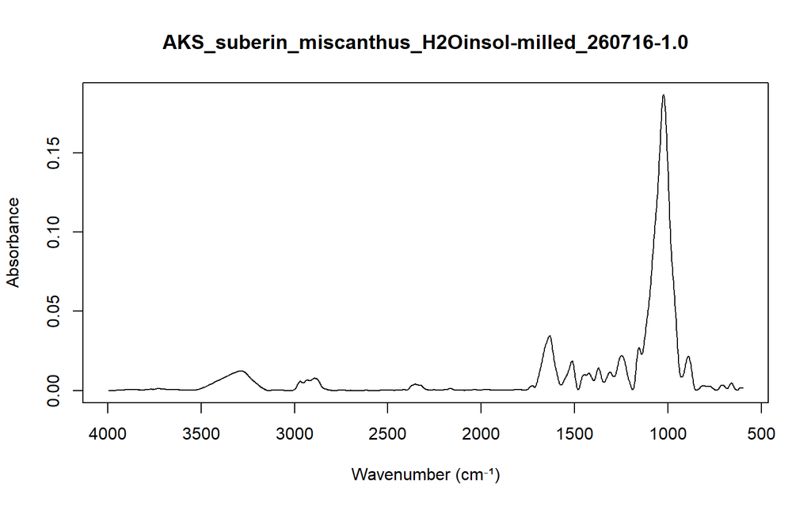

Metadata

| Parameter | Value |
| --- | --- |
| File Name | AKS_suberin_miscanthus_H2Oinsol-milled_260716-1.0 |
| Timestamp | 2026-07-16 16:20:04 GMT+1 |
| Max Y | 0.18670928478241 |
| Min Y | -0.000179093971382827 |
| Aperture Setting | 6 mm |
| Scanner Velocity | 10.0A |
| Result Spectrum | TR |
| Resolution | 4 |
| Sample Scans | 128 |
| End Frequency | 600 |
| Start Frequency | 4000 |
| Duration | 106.717002868652 |
| Experiment (method) | MIR_Invenio R_ATR - RT-DLaTGs_AKS.xpm |

#### Spectrum 5 : AKS_suberin_miscanthus_NaOH20_260629-0.0

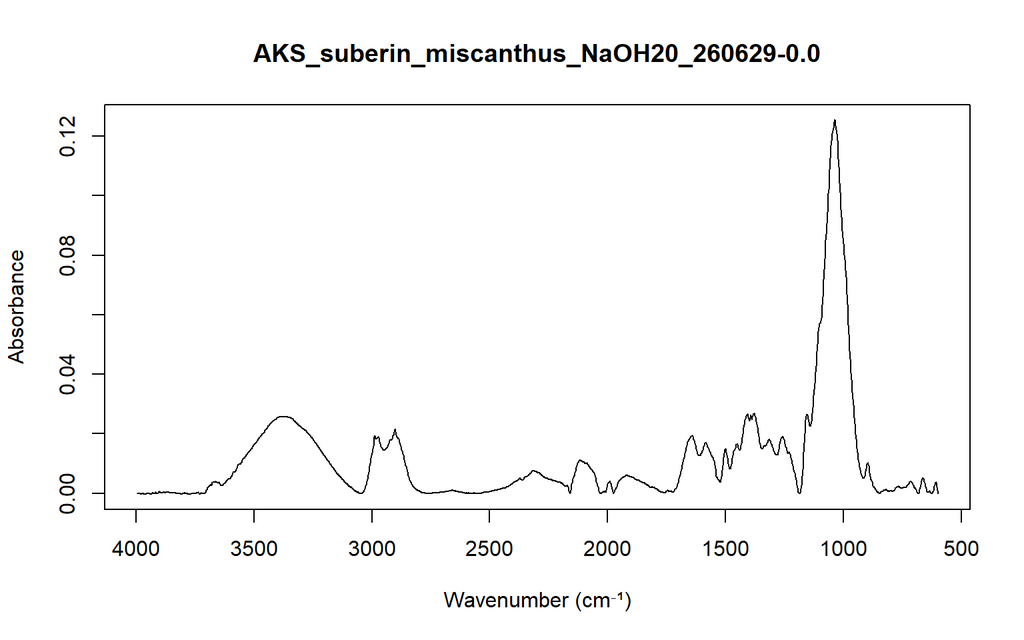

Metadata

| Parameter | Value |
| --- | --- |
| File Name | AKS_suberin_miscanthus_NaOH20_260629-0.0 |
| Timestamp | 2026-06-29 16:39:01 GMT+1 |
| Max Y | 0.125490769743919 |
| Min Y | -0.00032438532798551 |
| Aperture Setting | 6 mm |
| Scanner Velocity | 10.0A |
| Result Spectrum | TR |
| Resolution | 4 |
| Sample Scans | 128 |
| End Frequency | 600 |
| Start Frequency | 4000 |
| Duration | 106.716003417969 |
| Experiment (method) | MIR_Invenio R_ATR - RT-DLaTGs.xpm |

#### Spectrum 6 : AKS_suberin_miscanthus_NaOH20_260629-1.0

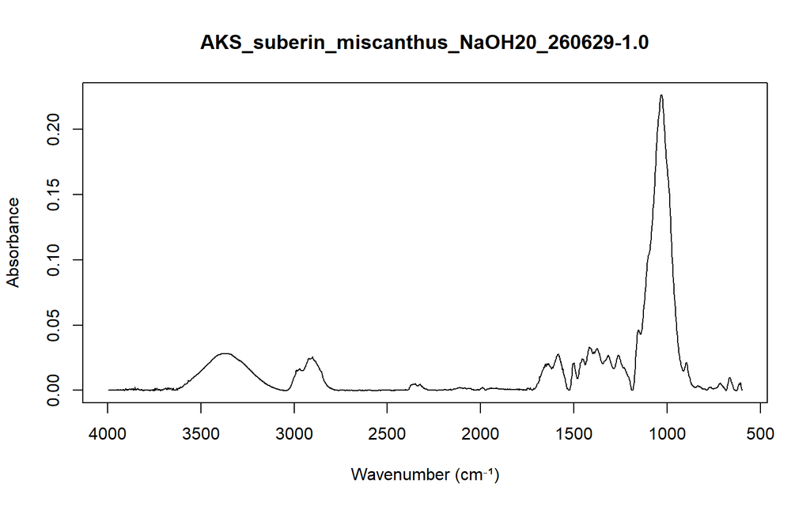

Metadata

| Parameter | Value |
| --- | --- |
| File Name | AKS_suberin_miscanthus_NaOH20_260629-1.0 |
| Timestamp | 2026-06-29 16:39:06 GMT+1 |
| Max Y | 0.226468488574028 |
| Min Y | -0.000295982812531292 |
| Aperture Setting | 6 mm |
| Scanner Velocity | 10.0A |
| Result Spectrum | TR |
| Resolution | 4 |
| Sample Scans | 128 |
| End Frequency | 600 |
| Start Frequency | 4000 |
| Duration | 106.714996337891 |
| Experiment (method) | MIR_Invenio R_ATR - RT-DLaTGs.xpm |

#### Spectrum 7 : AKS_suberin_miscanthus_NaOH30_260629-0.0

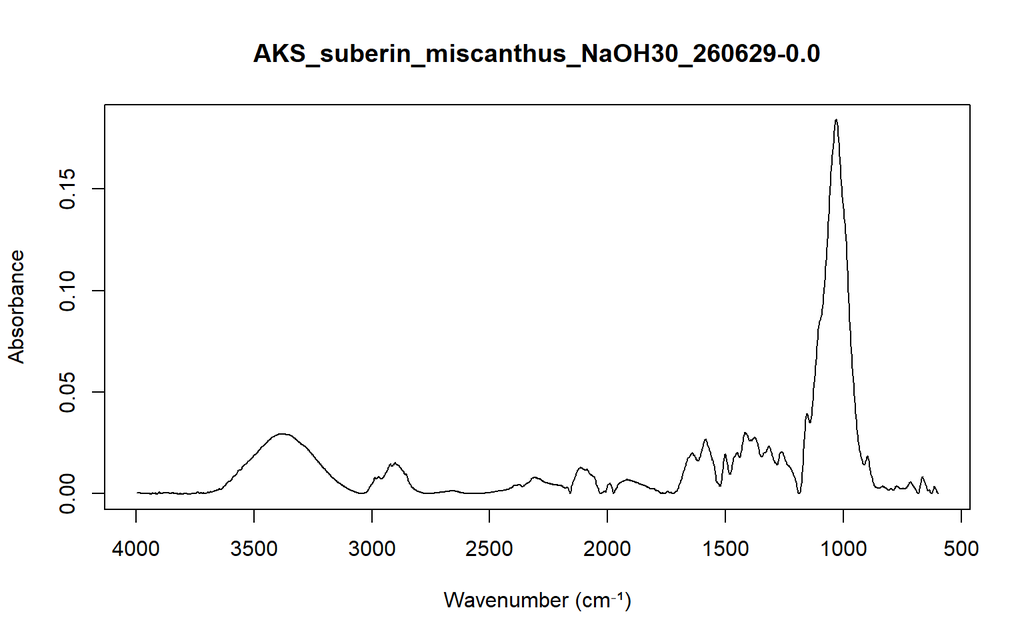

Metadata

| Parameter | Value |
| --- | --- |
| File Name | AKS_suberin_miscanthus_NaOH30_260629-0.0 |
| Timestamp | 2026-06-29 16:39:25 GMT+1 |
| Max Y | 0.184150665998459 |
| Min Y | -0.000391685112845153 |
| Aperture Setting | 6 mm |
| Scanner Velocity | 10.0A |
| Result Spectrum | TR |
| Resolution | 4 |
| Sample Scans | 128 |
| End Frequency | 600 |
| Start Frequency | 4000 |
| Duration | 106.716003417969 |
| Experiment (method) | MIR_Invenio R_ATR - RT-DLaTGs.xpm |

#### Spectrum 8 : AKS_suberin_miscanthus_NaOH30_260629-1.0

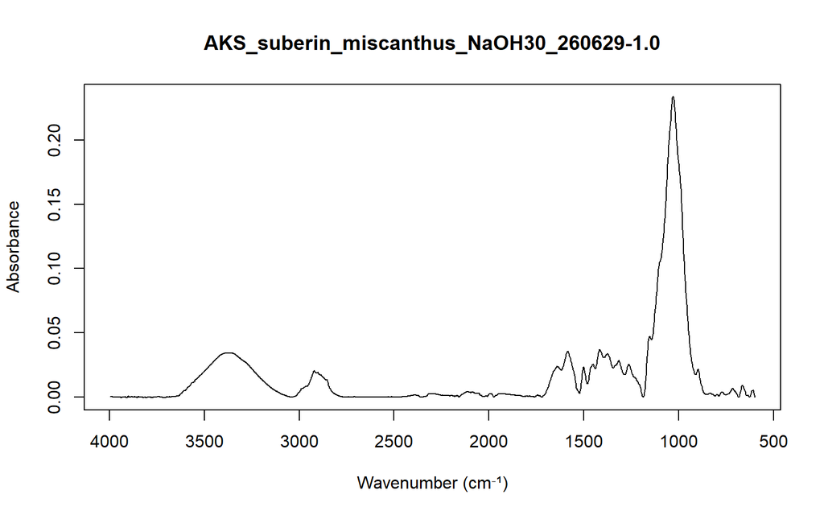

Metadata

| Parameter | Value |
| --- | --- |
| File Name | AKS_suberin_miscanthus_NaOH30_260629-1.0 |
| Timestamp | 2026-06-29 16:39:31 GMT+1 |
| Max Y | 0.234035298228264 |
| Min Y | -0.000584060500841588 |
| Aperture Setting | 6 mm |
| Scanner Velocity | 10.0A |
| Result Spectrum | TR |
| Resolution | 4 |
| Sample Scans | 128 |
| End Frequency | 600 |
| Start Frequency | 4000 |
| Duration | 106.714996337891 |
| Experiment (method) | MIR_Invenio R_ATR - RT-DLaTGs.xpm |

#### Spectrum 9 : AKS_suberin_miscanthus_raw-milled_260716-0.0

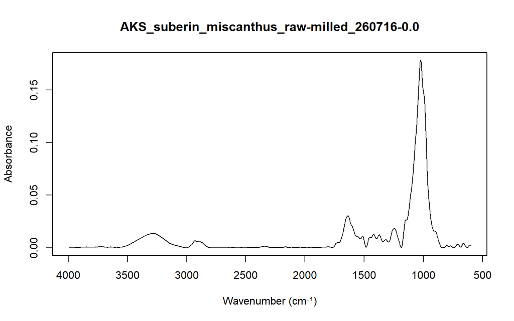

Metadata

| Parameter | Value |
| --- | --- |
| File Name | AKS_suberin_miscanthus_raw-milled_260716-0.0 |
| Timestamp | 2026-07-16 16:19:56 GMT+1 |
| Max Y | 0.178338885307312 |
| Min Y | -0.000173711872776039 |
| Aperture Setting | 6 mm |
| Scanner Velocity | 10.0A |
| Result Spectrum | TR |
| Resolution | 4 |
| Sample Scans | 128 |
| End Frequency | 600 |
| Start Frequency | 4000 |
| Duration | 106.717002868652 |
| Experiment (method) | MIR_Invenio R_ATR - RT-DLaTGs_AKS.xpm |

#### Spectrum 10 : AKS_suberin_miscanthus_raw_260629-0.0

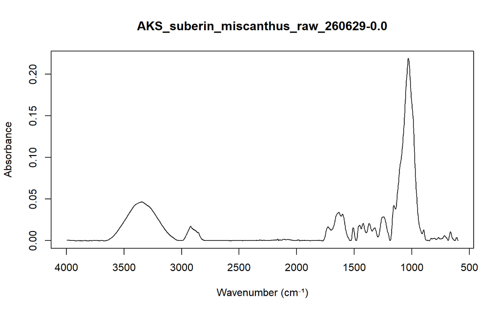

Metadata

| Parameter | Value |
| --- | --- |
| File Name | AKS_suberin_miscanthus_raw_260629-0.0 |
| Timestamp | 2026-06-29 16:38:15 GMT+1 |
| Max Y | 0.218940287828445 |
| Min Y | -0.000332921219523996 |
| Aperture Setting | 6 mm |
| Scanner Velocity | 10.0A |
| Result Spectrum | TR |
| Resolution | 4 |
| Sample Scans | 128 |
| End Frequency | 600 |
| Start Frequency | 4000 |
| Duration | 106.714996337891 |
| Experiment (method) | MIR_Invenio R_ATR - RT-DLaTGs.xpm |

#### Spectrum 11 : AKS_suberin_sorghum_H2Oinsol-milled_260716-0.0

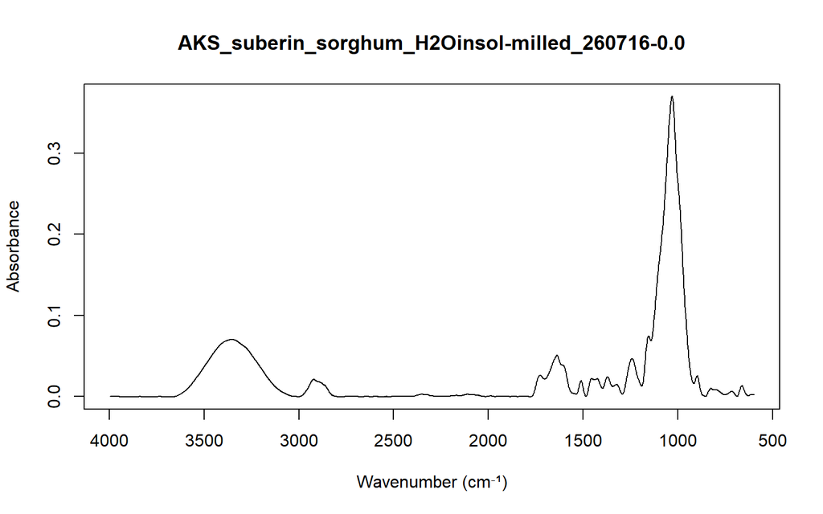

Metadata

| Parameter | Value |
| --- | --- |
| File Name | AKS_suberin_sorghum_H2Oinsol-milled_260716-0.0 |
| Timestamp | 2026-07-16 16:20:18 GMT+1 |
| Max Y | 0.370099663734436 |
| Min Y | -0.000468645477667451 |
| Aperture Setting | 6 mm |
| Scanner Velocity | 10.0A |
| Result Spectrum | TR |
| Resolution | 4 |
| Sample Scans | 128 |
| End Frequency | 600 |
| Start Frequency | 4000 |
| Duration | 106.718002319336 |
| Experiment (method) | MIR_Invenio R_ATR - RT-DLaTGs_AKS.xpm |

#### Spectrum 12 : AKS_suberin_sorghum_H2Oinsol-milled_260716-1.0

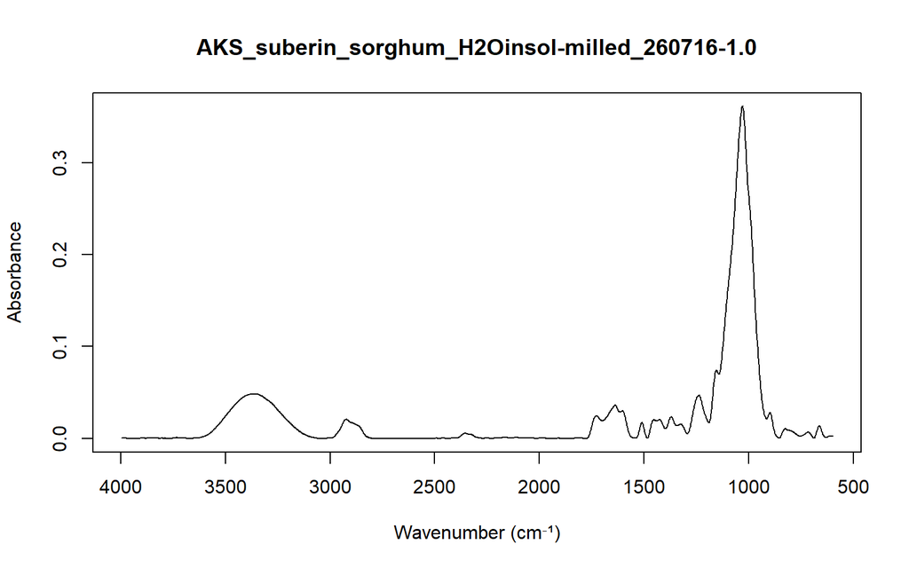

Metadata

| Parameter | Value |
| --- | --- |
| File Name | AKS_suberin_sorghum_H2Oinsol-milled_260716-1.0 |
| Timestamp | 2026-07-16 16:20:21 GMT+1 |
| Max Y | 0.361629277467728 |
| Min Y | -0.000377201795345172 |
| Aperture Setting | 6 mm |
| Scanner Velocity | 10.0A |
| Result Spectrum | TR |
| Resolution | 4 |
| Sample Scans | 128 |
| End Frequency | 600 |
| Start Frequency | 4000 |
| Duration | 106.718002319336 |
| Experiment (method) | MIR_Invenio R_ATR - RT-DLaTGs_AKS.xpm |

#### Spectrum 13 : AKS_suberin_sorghum_raw-milled_260716-0.0

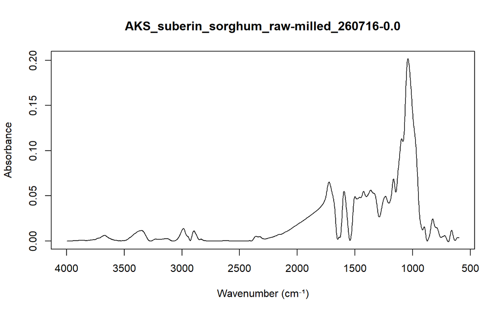

Metadata

| Parameter | Value |
| --- | --- |
| File Name | AKS_suberin_sorghum_raw-milled_260716-0.0 |
| Timestamp | 2026-07-16 16:20:07 GMT+1 |
| Max Y | 0.201839119195938 |
| Min Y | -0.000742447620723397 |
| Aperture Setting | 6 mm |
| Scanner Velocity | 10.0A |
| Result Spectrum | TR |
| Resolution | 4 |
| Sample Scans | 128 |
| End Frequency | 600 |
| Start Frequency | 4000 |
| Duration | 106.718002319336 |
| Experiment (method) | MIR_Invenio R_ATR - RT-DLaTGs_AKS.xpm |

#### Spectrum 14 : AKS_suberin_sorghum_raw-milled_260716-1.0

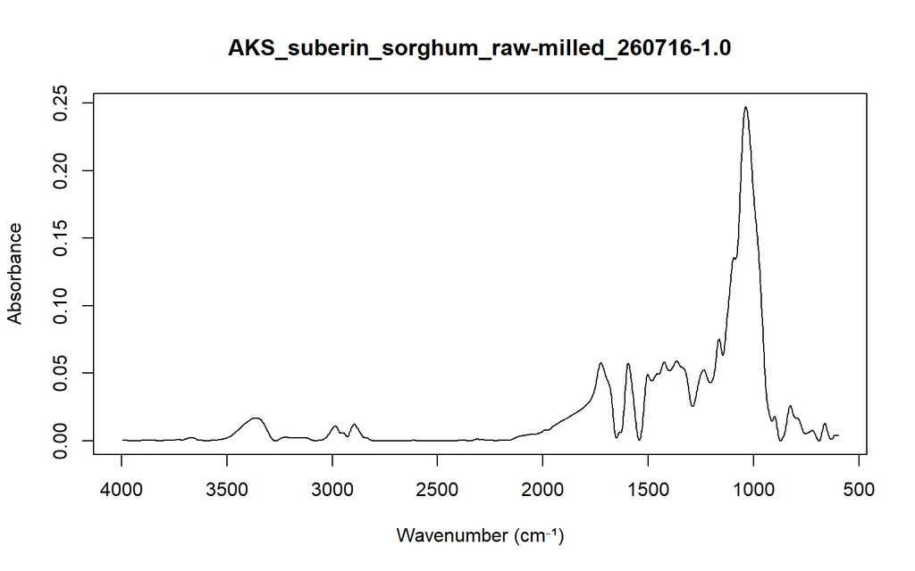

Metadata

| Parameter | Value |
| --- | --- |
| File Name | AKS_suberin_sorghum_raw-milled_260716-1.0 |
| Timestamp | 2026-07-16 16:20:10 GMT+1 |
| Max Y | 0.247244596481323 |
| Min Y | -0.000125114747788757 |
| Aperture Setting | 6 mm |
| Scanner Velocity | 10.0A |
| Result Spectrum | TR |
| Resolution | 4 |
| Sample Scans | 128 |
| End Frequency | 600 |
| Start Frequency | 4000 |
| Duration | 106.718002319336 |
| Experiment (method) | MIR_Invenio R_ATR - RT-DLaTGs_AKS.xpm |

#### Spectrum 15 : AKS_suberin_sorghum_raw-milled_260716-2.0

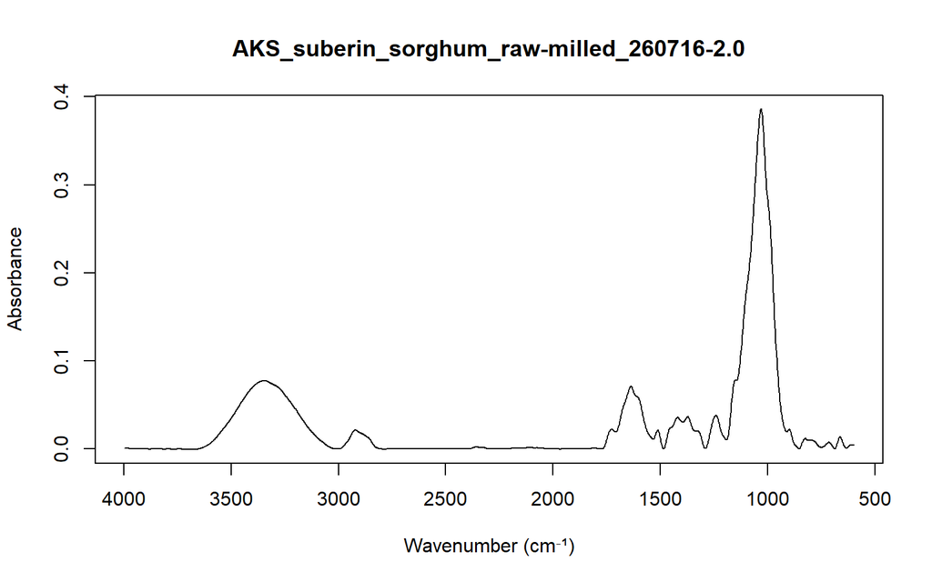

Metadata

| Parameter | Value |
| --- | --- |
| File Name | AKS_suberin_sorghum_raw-milled_260716-2.0 |
| Timestamp | 2026-07-16 16:20:14 GMT+1 |
| Max Y | 0.386217266321182 |
| Min Y | -0.000600139610469341 |
| Aperture Setting | 6 mm |
| Scanner Velocity | 10.0A |
| Result Spectrum | TR |
| Resolution | 4 |
| Sample Scans | 128 |
| End Frequency | 600 |
| Start Frequency | 4000 |
| Duration | 106.718002319336 |
| Experiment (method) | MIR_Invenio R_ATR - RT-DLaTGs_AKS.xpm |

#### Spectrum 16 : AKS_suberin_sorghum_raw_260702-1.0

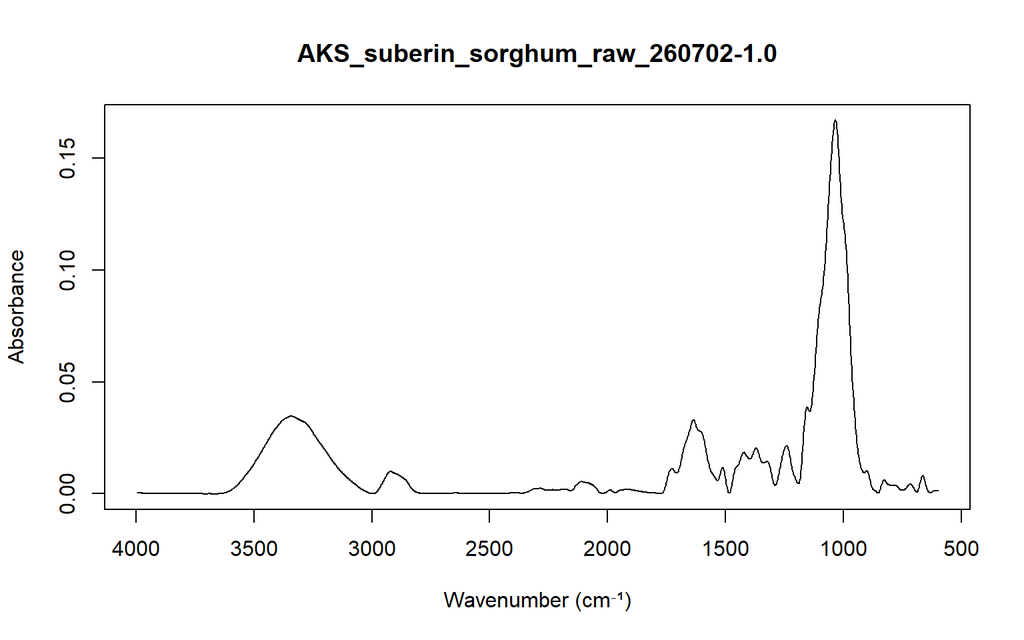

Metadata

| Parameter | Value |
| --- | --- |
| File Name | AKS_suberin_sorghum_raw_260702-1.0 |
| Timestamp | 2026-07-02 11:22:24 GMT+1 |
| Max Y | 0.167285069823265 |
| Min Y | -0.000325264787534252 |
| Aperture Setting | 6 mm |
| Scanner Velocity | 10.0A |
| Result Spectrum | TR |
| Resolution | 4 |
| Sample Scans | 128 |
| End Frequency | 600 |
| Start Frequency | 4000 |
| Duration | 106.714996337891 |
| Experiment (method) | MIR_Invenio R_ATR - RT-DLaTGs.xpm |

#### Spectrum 17 : AKS_suberin_sugarcane_H2Oinsol-milled_260716-0.0

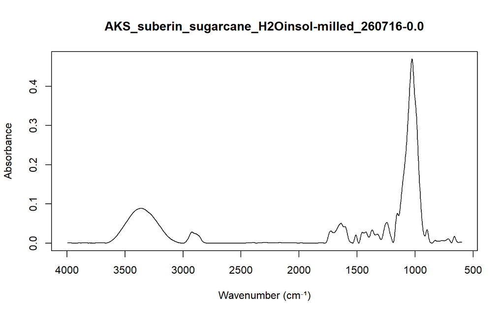

Metadata

| Parameter | Value |
| --- | --- |
| File Name | AKS_suberin_sugarcane_H2Oinsol-milled_260716-0.0 |
| Timestamp | 2026-07-16 16:20:30 GMT+1 |
| Max Y | 0.469949871301651 |
| Min Y | -0.000508723605889827 |
| Aperture Setting | 6 mm |
| Scanner Velocity | 10.0A |
| Result Spectrum | TR |
| Resolution | 4 |
| Sample Scans | 128 |
| End Frequency | 600 |
| Start Frequency | 4000 |
| Duration | 106.717002868652 |
| Experiment (method) | MIR_Invenio R_ATR - RT-DLaTGs_AKS.xpm |

#### Spectrum 18 : AKS_suberin_sugarcane_H2Oinsol-milled_260716-1.0

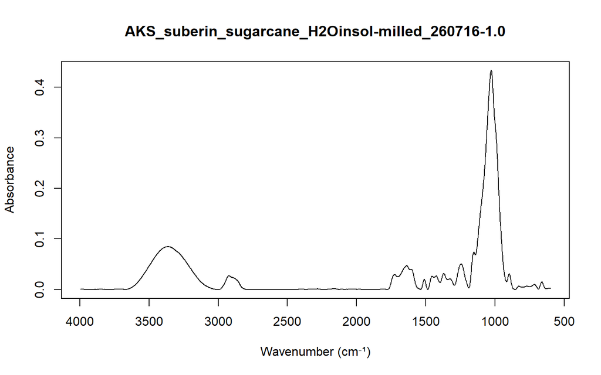

Metadata

| Parameter | Value |
| --- | --- |
| File Name | AKS_suberin_sugarcane_H2Oinsol-milled_260716-1.0 |
| Timestamp | 2026-07-16 16:20:34 GMT+1 |
| Max Y | 0.433760046958923 |
| Min Y | -0.000293551187496632 |
| Aperture Setting | 6 mm |
| Scanner Velocity | 10.0A |
| Result Spectrum | TR |
| Resolution | 4 |
| Sample Scans | 128 |
| End Frequency | 600 |
| Start Frequency | 4000 |
| Duration | 106.717002868652 |
| Experiment (method) | MIR_Invenio R_ATR - RT-DLaTGs_AKS.xpm |

#### Spectrum 19 : AKS_suberin_sugarcane_raw-milled_260716-0.0

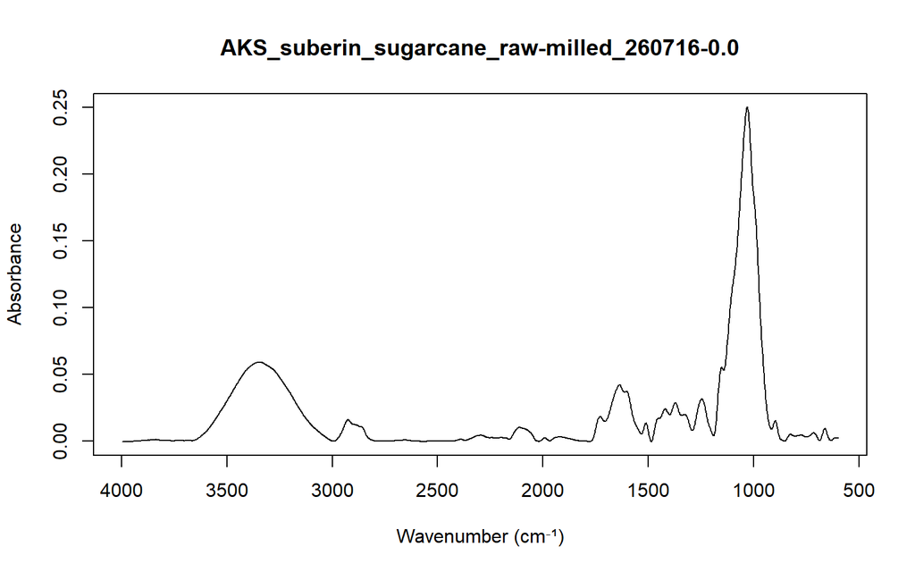

Metadata

| Parameter | Value |
| --- | --- |
| File Name | AKS_suberin_sugarcane_raw-milled_260716-0.0 |
| Timestamp | 2026-07-16 16:20:24 GMT+1 |
| Max Y | 0.250421524047852 |
| Min Y | -0.000320039718644693 |
| Aperture Setting | 6 mm |
| Scanner Velocity | 10.0A |
| Result Spectrum | TR |
| Resolution | 4 |
| Sample Scans | 128 |
| End Frequency | 600 |
| Start Frequency | 4000 |
| Duration | 106.717002868652 |
| Experiment (method) | MIR_Invenio R_ATR - RT-DLaTGs_AKS.xpm |

#### Spectrum 20 : AKS_suberin_sugarcane_raw-milled_260716-1.0

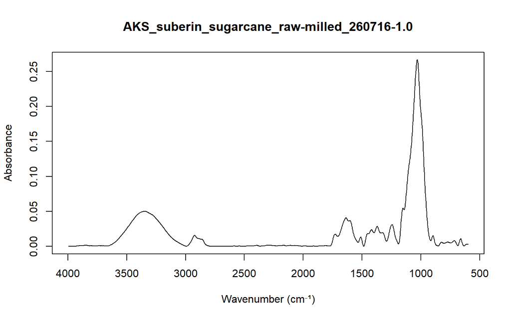

Metadata

| Parameter | Value |
| --- | --- |
| File Name | AKS_suberin_sugarcane_raw-milled_260716-1.0 |
| Timestamp | 2026-07-16 16:20:27 GMT+1 |
| Max Y | 0.267099052667618 |
| Min Y | -0.000253142759902403 |
| Aperture Setting | 6 mm |
| Scanner Velocity | 10.0A |
| Result Spectrum | TR |
| Resolution | 4 |
| Sample Scans | 128 |
| End Frequency | 600 |
| Start Frequency | 4000 |
| Duration | 106.718002319336 |
| Experiment (method) | MIR_Invenio R_ATR - RT-DLaTGs_AKS.xpm |

#### Spectrum 21 : AKS_suberin_sugarcane_raw_260702-0.0

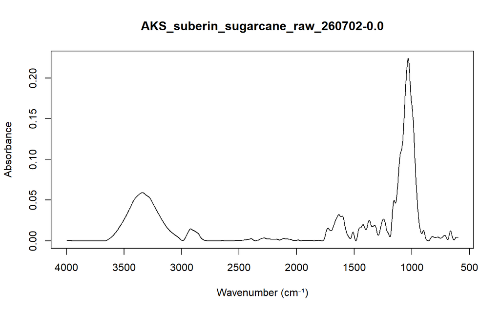

Metadata

| Parameter | Value |
| --- | --- |
| File Name | AKS_suberin_sugarcane_raw_260702-0.0 |
| Timestamp | 2026-07-02 11:22:37 GMT+1 |
| Max Y | 0.224100381135941 |
| Min Y | -0.000198189518414438 |
| Aperture Setting | 6 mm |
| Scanner Velocity | 10.0A |
| Result Spectrum | TR |
| Resolution | 4 |
| Sample Scans | 128 |
| End Frequency | 600 |
| Start Frequency | 4000 |
| Duration | 106.716003417969 |
| Experiment (method) | MIR_Invenio R_ATR - RT-DLaTGs.xpm |

#### Spectrum 22 : AKS_suberin_sugarcane_raw_260702-1.0

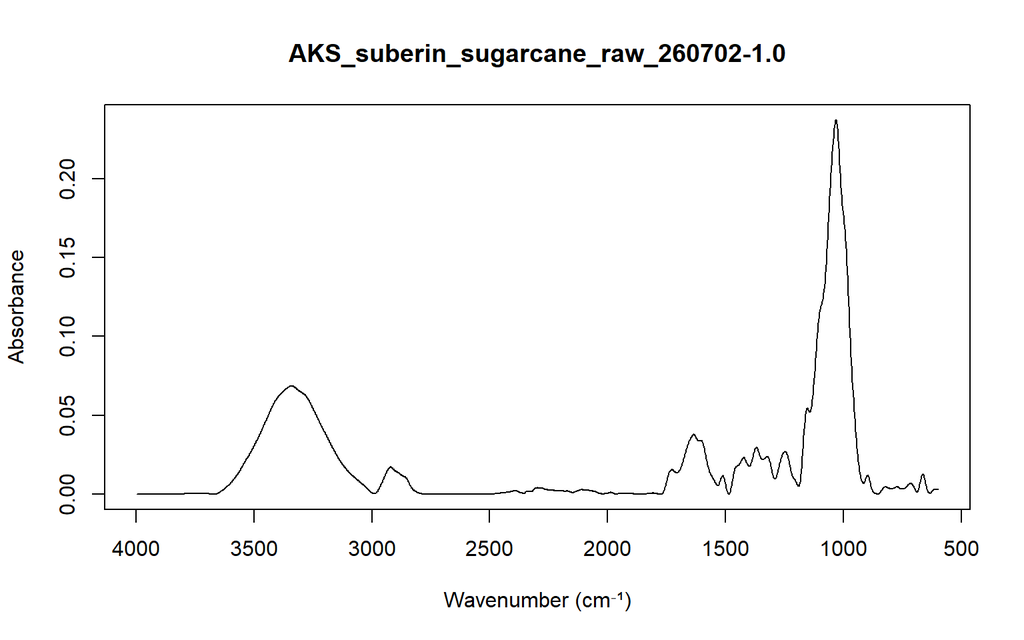

Metadata

| Parameter | Value |
| --- | --- |
| File Name | AKS_suberin_sugarcane_raw_260702-1.0 |
| Timestamp | 2026-07-02 11:22:40 GMT+1 |
| Max Y | 0.237447887659073 |
| Min Y | -0.0001230962225236 |
| Aperture Setting | 6 mm |
| Scanner Velocity | 10.0A |
| Result Spectrum | TR |
| Resolution | 4 |
| Sample Scans | 128 |
| End Frequency | 600 |
| Start Frequency | 4000 |
| Duration | 106.716003417969 |
| Experiment (method) | MIR_Invenio R_ATR - RT-DLaTGs.xpm |

## Stacking multiple spectra

### Stacking re-runs

This code looks for files with the same sample number and stacks their spectra, to check whether reruns are consistent.

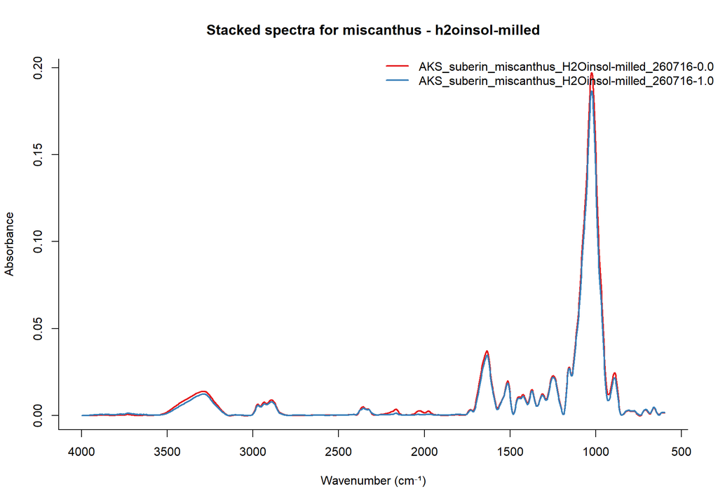

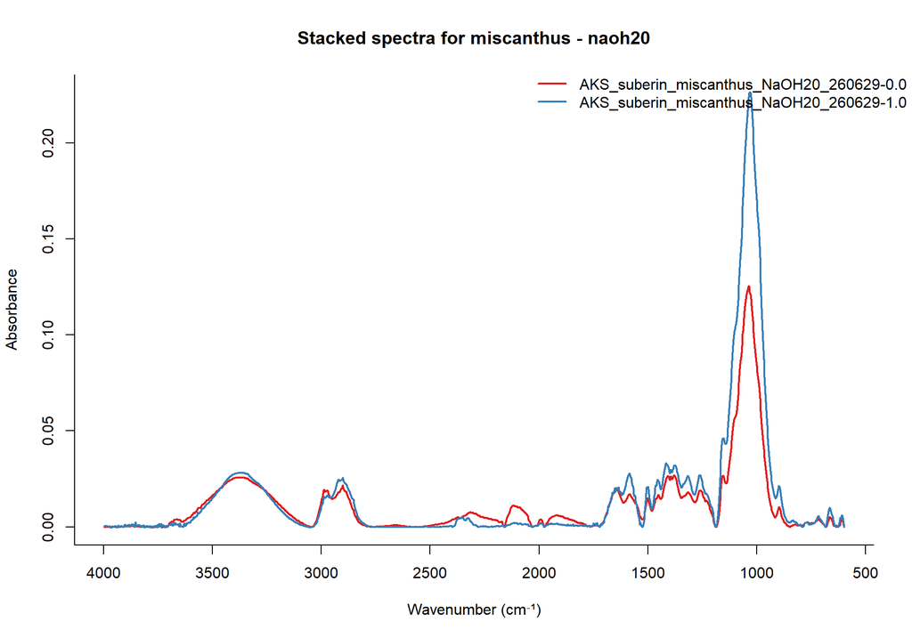

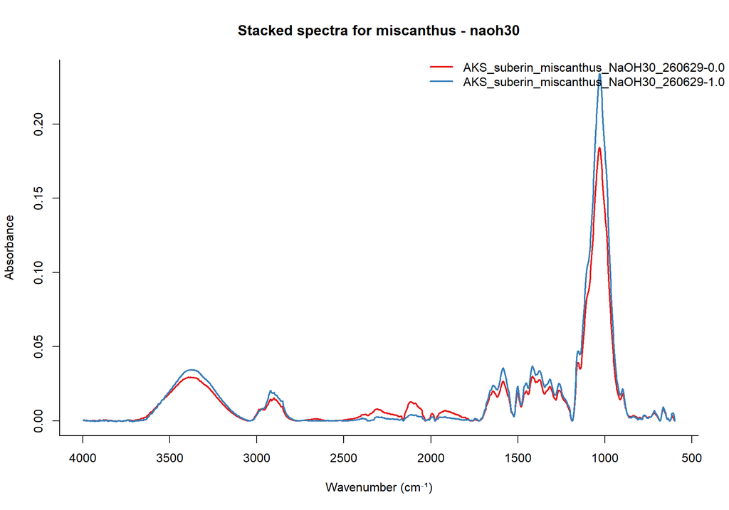

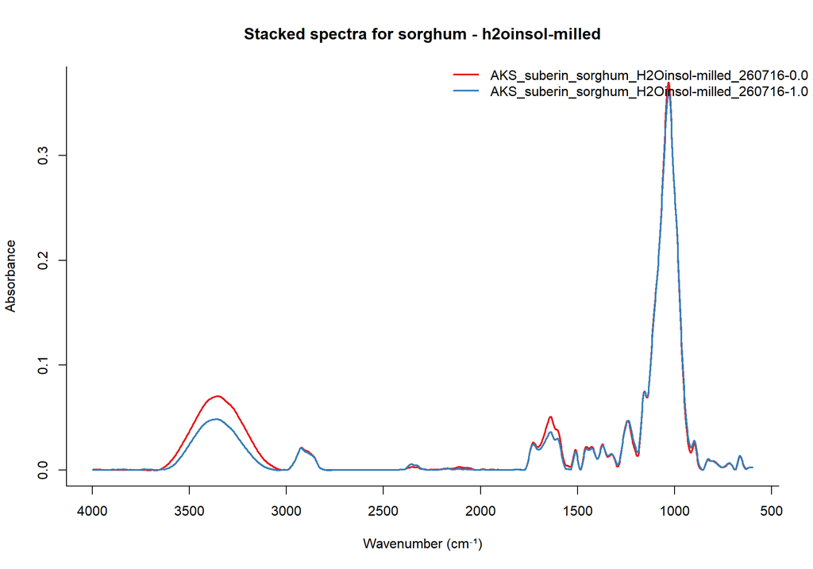

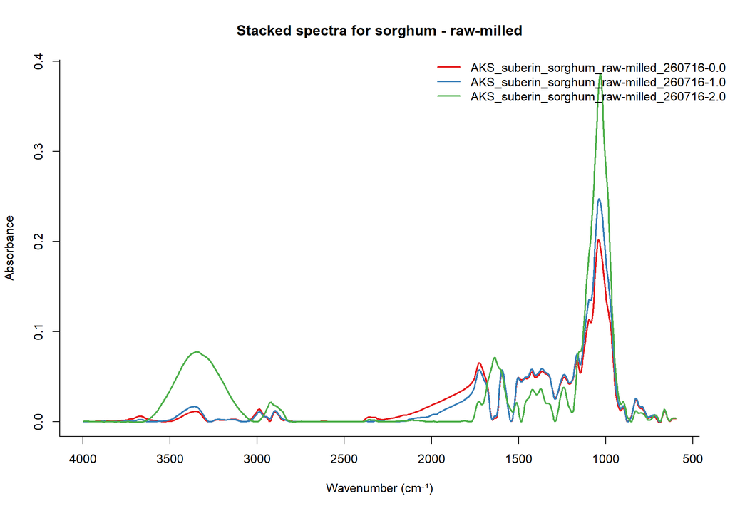

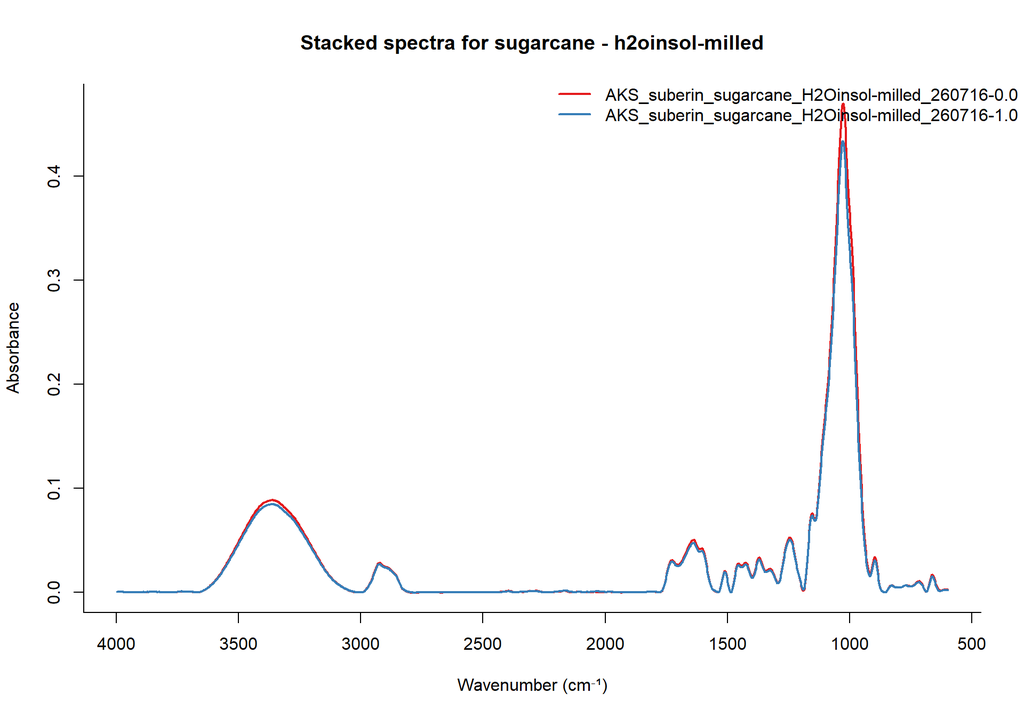

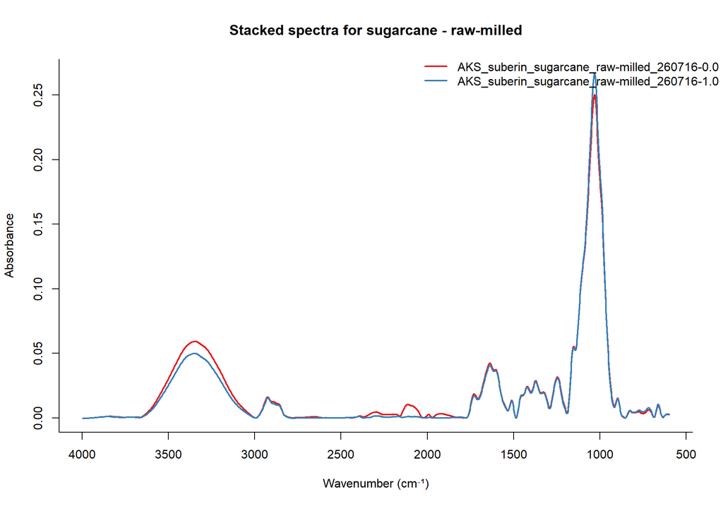

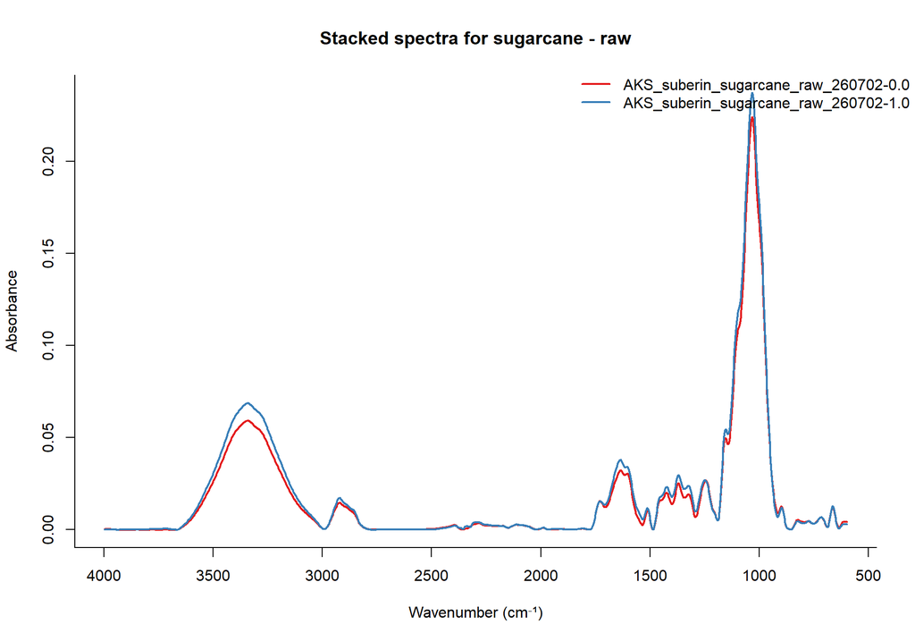

```r
knitr::opts_chunk$set(
  collapse = TRUE,
  comment = "#>",
  echo = TRUE,
  results = "markup",
  include = TRUE
)
library(opusreader2)
library(RColorBrewer)



data_test <- read_opus(dsn = corr_spectra)

# Helper to extract fields from filenames with the pattern
# AKS_suberin_[plant]_[washing-treatment]_[yymmdd]-[run].ext
extract_filename_fields <- function(filename) {
  parts <- strsplit(basename(filename), "_")[[1]]
  if (length(parts) >= 4) {
    list(
      plant = tolower(parts[3]),
      washing_treatment = tolower(parts[4])
    )
  } else {
    list(plant = NA, washing_treatment = NA)
  }
}

# Change this vector to c("plant") or c("washing_treatment") if you want
# to group on just one field instead of the plant-treatment pair.
grouping_fields <- c("plant", "washing_treatment")

file_fields <- lapply(names(data_test), extract_filename_fields)
plants <- vapply(file_fields, `[[`, character(1), "plant")
washing_treatments <- vapply(file_fields, `[[`, character(1), "washing_treatment")
group_df <- data.frame(
  plant = plants,
  washing_treatment = washing_treatments,
  stringsAsFactors = FALSE
)

group_keys <- do.call(paste, c(as.list(group_df[grouping_fields]), list(sep = "_")))
unique_combinations <- unique(group_keys[complete.cases(
  group_df[grouping_fields]
)])

# Plot stacked spectra for each unique combination
library(RColorBrewer)
for (combination in unique_combinations) {
  idx <- which(group_keys == combination)
  if (length(idx) > 1) {
    # Extract the configured grouping fields from the combination key
    parts <- strsplit(combination, "_")[[1]]
    plant <- if ("plant" %in% grouping_fields) parts[match("plant", grouping_fields)] else NA
    washing_treatment <- if ("washing_treatment" %in% grouping_fields) parts[match("washing_treatment", grouping_fields)] else NA

    spectra <- data_test[idx]
    colors <- brewer.pal(min(length(spectra), 8), "Set1")
    plot(NULL, xlim = rev(range(spectra[[1]]$ab$wavenumbers)),
         ylim = range(sapply(spectra, function(x) x$ab$data), na.rm = TRUE),
         xlab = "Wavenumber (cm⁻¹)", ylab = "Absorbance",
         main = paste("Stacked spectra for", paste(parts, collapse = " - ")),
         bty = "l")
    for (i in seq_along(spectra)) {
      ab_data <- spectra[[i]]$ab
      if (!is.null(ab_data) && !is.null(ab_data$wavenumbers) &&
            !is.null(ab_data$data)) {
        lines(ab_data$wavenumbers, ab_data$data, col = colors[i], lwd = 2)
      }
    }
    legend("topright",
           inset = c(-0.05, -0.02),
           legend = names(spectra),
           col = colors[seq_along(spectra)],
           lwd = 2,
           xpd = TRUE,
           bty = "n")
  }
}
```